# presentation on git, a DVCS

Sitaram Chamarty (sitaramc@gmail.com)

# 1 preface

# 1.1 why

[figure not shown]

# 1.2 why use a VCS

- reversibility or rollback, aka C-Y-A!
  - linear (on the time axis), simple to implement
- concurrency
  - non-linear, all the complexity is here
  - make or break productivity
    - individual productivity also, if it can make context switching trivial
- annotation

# 1.3 VCSs in common use

- open source
  - CVS
  - SVN (Subversion)
  - Darcs/TLA/Bazaar/Monotone, Mercurial, Git
- proprietary
  - VSS, Clearcase, Perforce
  - Bitkeeper
  - others??

# 2 DVCSs and git

# 2.1 “distributed”?

- every dev has his/her own repository
  - on their own workstation
  - no single point of failure/contention
- all repos are (usually) “clones” of the central repository
- easy to work offline
  - e.g., long weekend+laptop :-)
  - commits made while offline retain their identity
  - they don’t get collapsed into one big commit
- commit-then-merge, not merge-then-commit

# 2.2 disconnected operation

- local caching: how much is cached locally when you check out?
  - CVS: working copy of specific version, plus info about what version was checked out
  - SVN: CVS, plus extra copy of the specified version
  - BZR/HG: SVN, plus complete history of current branch
  - GIT: BZR/HG, plus complete history of ALL branches!

# 2.3 notes on above

- CVS: Anything other than edit needs network access, even a diff between your working copy and the currently checked out version
- SVN: Diffs between working copy and any other version need network
- BZR/HG: Comparing to a different branch or switching to it needs network
- VSS
  - no network access except via “shares”, so local teams only
  - no atomic commits!
  - no merge tracking
  - repository corruption

# 2.4 what’s different about git?

- cryptographically secure integrity checks builtin
- fast
  - most operations are local
  - network operations are highly optimised
  - **ideal** for distributed teams
- easy to setup/deploy
  - server requires minimal hardware
  - no license costs

# 2.5 what’s different about git? (cont’d)

- very small repo size
  - Mozilla repo in CVS: 2.7 GB
  - imported to SVN 8.2 GB
  - imported to GIT: 450 MB!
  - (a full checkout is 350 MB)
- very, very, cheap branching
- excellent merging

# 2.6 caveats about git

- no partial checkouts – it’s the whole project or nothing
  - but you can use the “submodule” mechanism if you know in advance what pieces will be separately needed
- will not track
  - permissions and ownership, except the “x” (executable) bit
    - in unix terms, only cares about the first “x” in rwxrwxrwx
  - empty directories
- not optimised for tracking **very large** binary files (movies, etc.)

# 2.7 history

- initially designed as a file system!
- originally only a backend, now all in one
- reputation for being hard to use, now no longer valid
- focus on large projects with many developers
  - but that doesn’t mean small projects can’t use it
  - remember: multi-tasking

# 3 understanding git

# 3.1 working with git

- CLI is the most powerful
- don’t like the CLI?
  - 3 excellent GUI tools come with git
  - very powerful; for an excellent intro to these tools, see https://nathanj.github.com/gitguide
  - plugins: Eclipse and VS plugins available
  - but you miss many features **unique** to git if you only use these plugins

# 3.2 some mindset changes needed…

- learn to make many fine-grained commits rather than a few large ones
- commit locally before performing any remote operations
  - example, in the typical “svn update” scenario, if your changes are not yet ready to be sent to the server, you can either
    - avoid doing the update
    - do it and pray :-)
  - in git, you just commit locally before doing the “git pull”

# 3.3 normal workflow - CVCSs

[figure not shown]

# 3.4 normal workflow - most DVCSs

[figure not shown]

# 3.5 normal workflow - Git

[figure not shown]

# 3.6 something unique to git

- index
  - a staging area for the next commit
  - stuff gets sent here when you “add”
  - when you “commit”, the current index is turned into a real commit object
- helps in reviewing changes
- helps when fixing conflicts during a complex merge

# 4 legacy systems versus git

# 4.1 problems in SVN

- slow on large repositories
- .SVN directories all over the place
  - often as large as the entire git repo!
- refactor/rename support missing
- branching is fine…
  - but merging…?

# 4.2 problems in SVN (cont’d)

- merge tracking not very well done
  - does not record who did the branch (attributes all changes to the dev who did the merge)
  - does not record “merge-only” changes separately from the two branches
  - can make repeated merges very difficult
    - SVN mergeinfo has many limitations
- merges can be slow
- large merges can be painful

# 4.3 branching in most older VCSs

- branching is considered advanced and people avoid it
  - either the tool has no branching,
  - or has really bad merging
- and branching is useless without good merging
- so lots of parallelism goes unused
  - or you need “SCM admins” to do the merge!

# 4.4 problems in SVN (cont’d)

- lack of local commits
  - you don’t want to “break the build”
  - so you keep lots of uncommitted changes outside the VCS
  - and do one big checkin when you’re ready

# 4.5 productivity advantages of git

- history tracking handled much better; makes repeated merges a breeze
  - all “commits” identified by a SHA-1 checksum
    - this is what gives it the cryptographically secure integrity check)
  - a branch is just a pointer to some commit
  - every commit records its parent commit’s sha
  - a merge is just a commit with more than one parent commit
- so, every commit knows all of its ancestors
  - regardless of repository, branch, etc

# 4.6 Linus on merging

- merging is the most important activity
  - “I merge 22,000 files several times a day, and I get unhappy if a merge takes more than 5 seconds” – Linus
  - the linux kernel has 22000 files and has averaged 4.5 merges/day over the last 2 years

# 4.7 Linus on merging (cont’d)

- make it fast and painless
  - …and people will start using it every day
- merge often, merge early
- otherwise you have huge conflicts to resolve later!

# 4.8 Linus on merging (cont’d)

```
https://git.or.cz/gitwiki/LinusTalk200705Transcript

If you can do something really fast, really well, people will start using
it differently. One of the things I wanted to make sure is that merges go
really really quickly because I want people to merge often and merge
early, because as it turns out it becomes easier to merge. If you merge
every day, suddenly you never get to the point where you have huge
conflicts that are hard to resolve. So if you actually make branching and
merging easy, you actually avoid a whole class of problems that you
otherwise have a really really hard time avoiding.
```

# 4.9 productivity advantages of git (cont’d)

- complex merges handled much better; frees devs from worrying about it most of the time
  - merges involving renames
  - criss-cross merges
- encourages many small commits instead of few large commits
  - easier code reviews
  - easier debugging
  - easier cherry picking
  - easier merging/rebasing (conflict resolution happens in much smaller units)

# 4.10 productivity advantages of git (cont’d)

- encourages creating local branches
  - no need to pollute the central server
  - experimental code can be developed “on the side”
    - if it works, promote it to the central server, with the full history of commits intact
    - otherwise, delete it; no need to immortalise failed experiments on the central server :-)
  - branch **names** are also local
    - we can all have a branch called “my-test” or “test” or whatever, without worrying about “is someone else using the same branch name?”

# 4.11 productivity advantages of git (cont’d)

- encourages using the tools available
  - important vcs operations (like “diff”) do not need network access
  - blazingly fast
    - even against a very old revision
    - or a version in some other branch
  - centralised VCSs take too long
    - painful to use
    - so programmers avoid them (?)

# 4.12 above stuff mostly from

- https://www.bitkeeper.com/Comparisons.html has subsections like https://www.bitkeeper.com/Comparisons.CVS.html and so on
- excellent resource, but knowing Mr McVoy, a little NaCl may be useful :)

# 5 examples and canned demos

# maintainability – refactor/rename support

- in most VCSs, renaming a file
  - is treated as a copy+delete
  - loses history (?)
- how about…
  - rename + move + edit a file in one branch
  - while making some bugfixes to it in another?
- git handles this without any fuss – demo 09

#### developer 1

(notice current branch is master)

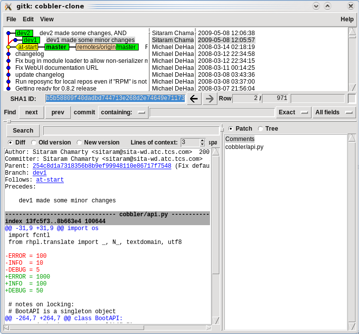

#### developer 2

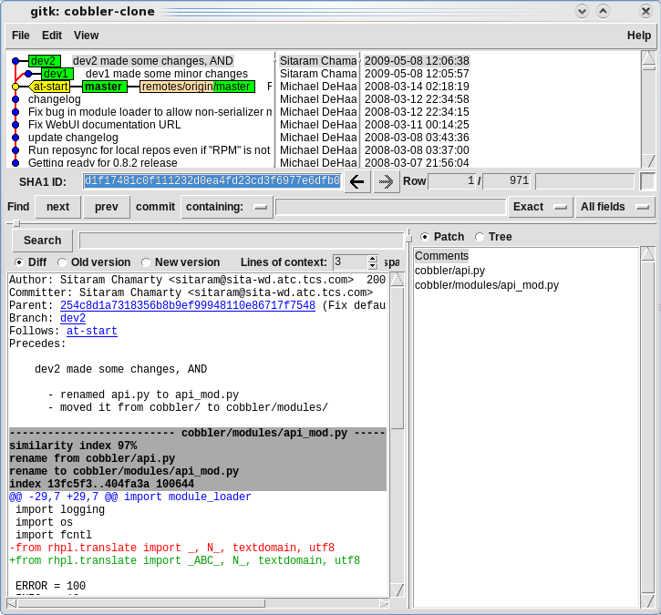

#### start a merge in ‘git gui’

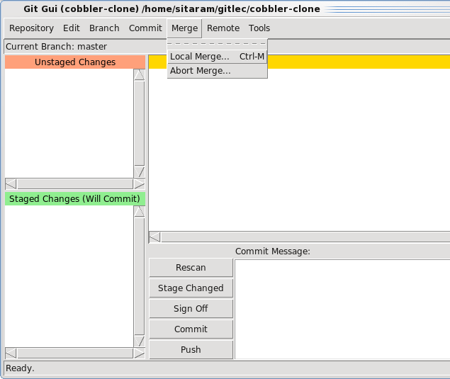

#### merge dev1 into master

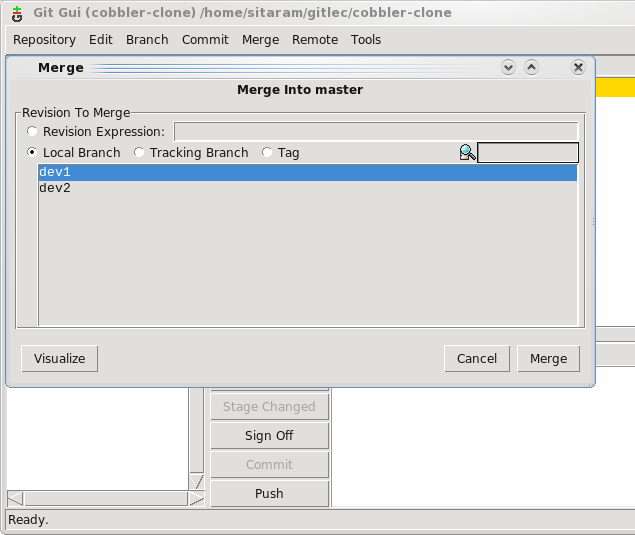

#### merge done

[figure not shown]

#### view in gitk

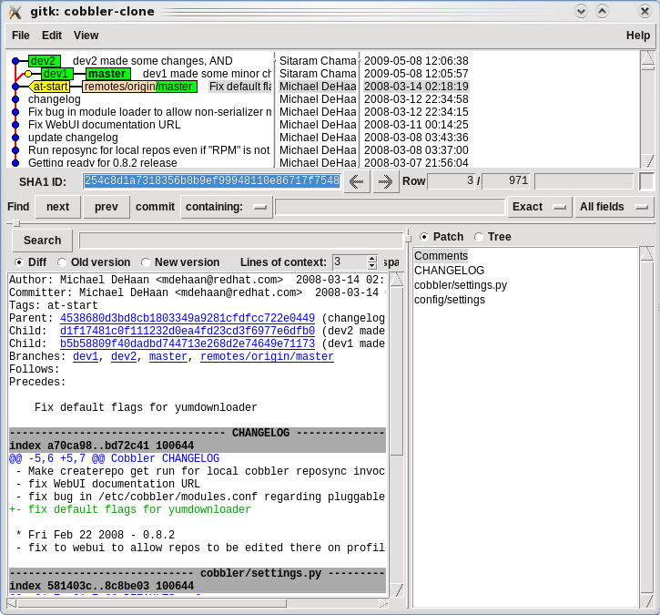

#### merge dev2 now

[figure not shown]

#### done

(Note the details of the merge!)

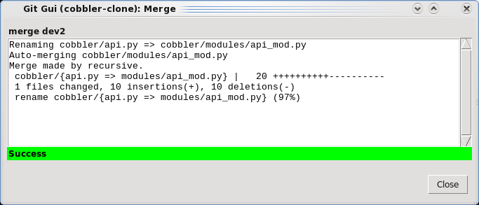

#### view in gitk

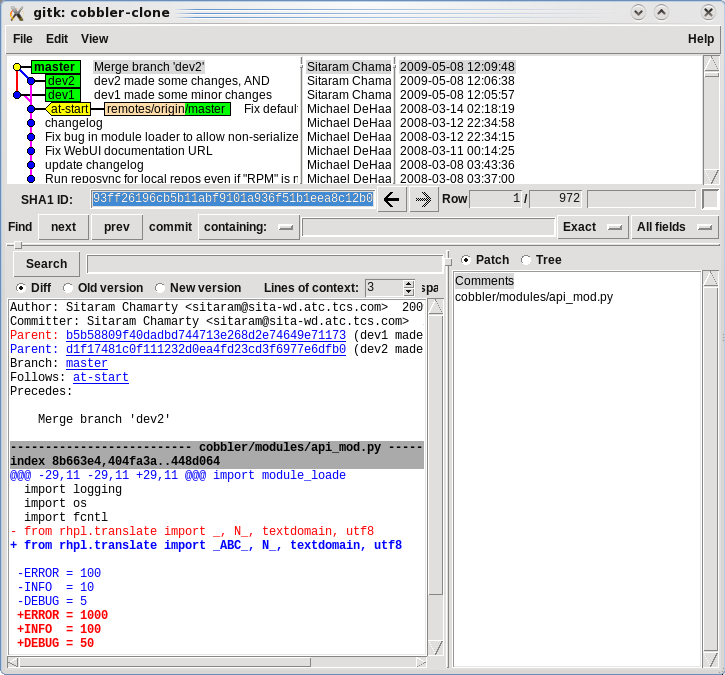

#### start a diff in gitk

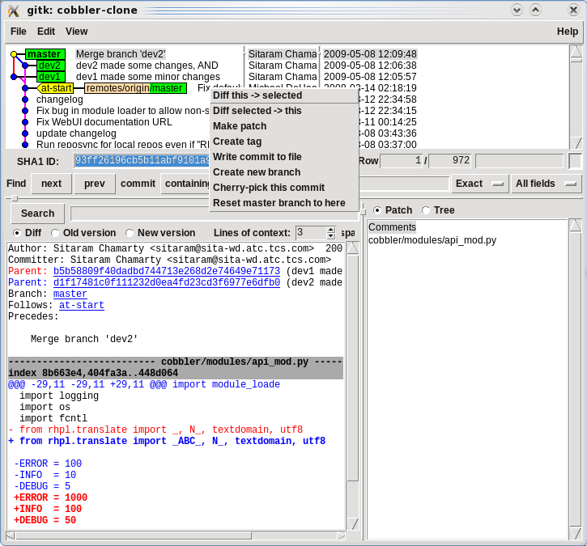

#### view diff (old and new master)

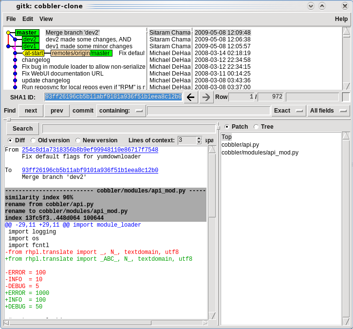

# maintainability: code movement detection

- example
  - move an important function with lots of history to some other file
- what would other VCSs do to the **history**?
- next 5 slides show code movement
  - displayed using “git gui blame”, one of the 3 GUI tools that come with git

#### open ‘git gui blame bundle.c’

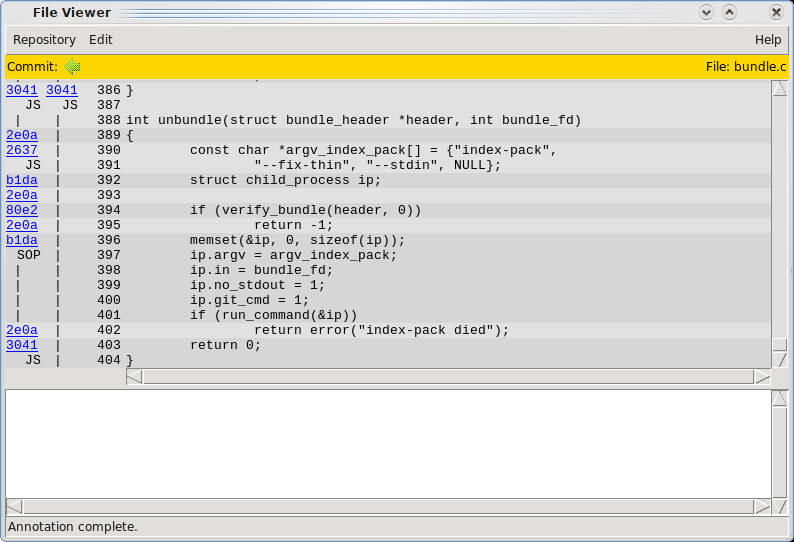

#### hover mouse on line 389

…and see what you get (no other VCS can do this!)

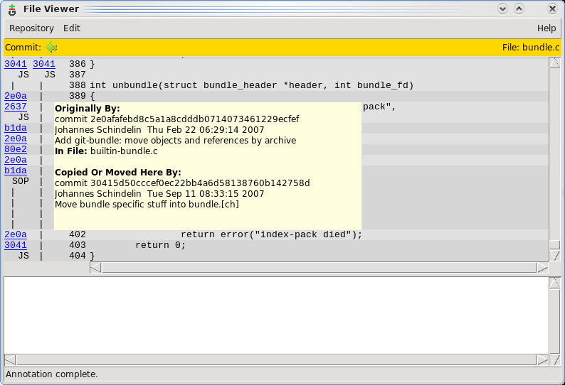

#### now line 396

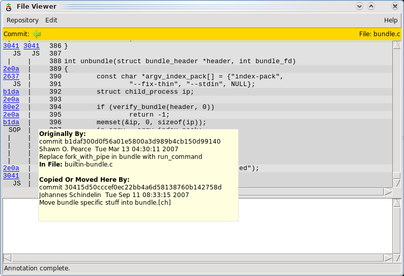

#### hover on the SHA

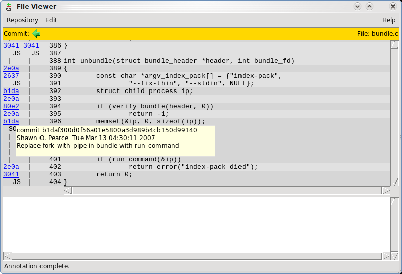

#### clicking on the SHA takes you to there

(notice it’s a different file!)

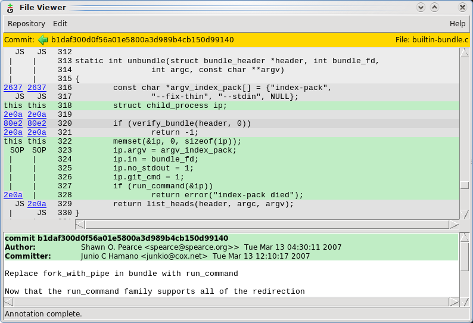

# maintainability: code movement detection (cont’d)

- this is **way** beyond what any other VCS can even dream of
- great help for new people trying to understand existing code base
- here’s a secret…
  - the information you see is not **stored** in the repository
  - it is **computed** on demand, dynamically!
  - which means you can get the same tracability for all your existing code
    - simply by converting to git!

# maintainability: revision history viewer

- git has another GUI to show you the version history graph
  - very intuitive, shows merges etc very nicely
  - lots of “right click” options in various places, to help track things down…
  - (one small example follows; there are many, many, more features – there is not enough time to talk about more!)

#### open gitk

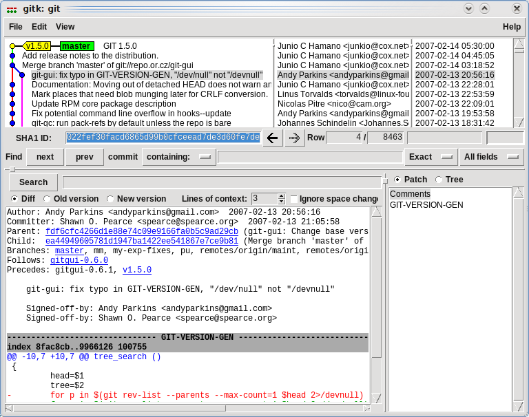

#### right click a changed line

(or deleted line) and choose “Show origin…”

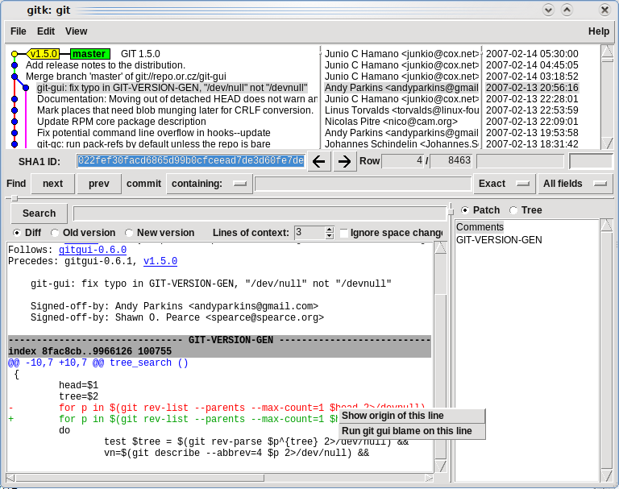

#### and it’ll take you there!

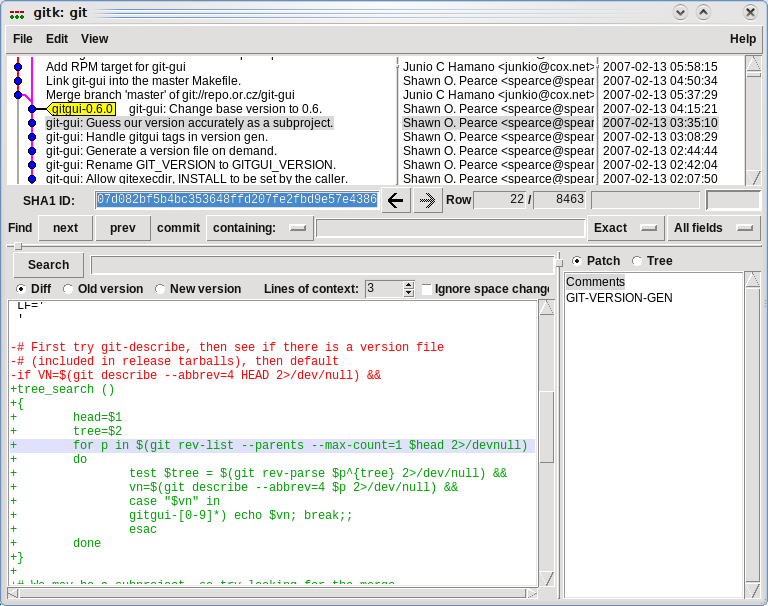

# 6 concepts again

# 6.1 git concepts

- repo
  - self-contained; remove “.git” and it’s all gone
- branch
  - active line of development
  - a repo can track any number of branches
- master
  - default branch in a new git project

# 6.2 concept detail: branches

- easy and inexpensive
- can have separate branches for separate features
- many being worked on “simultaneously”!
- you can switch rapidly between branches
- boosts individual productivity as well as team productivity
- almost all existing VCSs suck at this

# 6.3 git concepts (cont’d)

- working tree
  - is associated with only one branch
- head
  - the tip of a branch
- HEAD
  - the tip of the branch associated with your working tree; this is where commits go

# 6.4 git concepts (cont’d)

- index: holding area for changes approved for commit
  - git tracks content, not files
  - lets you select some files to commit while postponing others
  - lets you keep uncommited changes hanging around
- remote
- origin

# 6.5 some more git concepts

- commit ancestry
- commit ancestry as a DAG
  - the essence of git is to build and traverse this DAG

# 6.6 CVS/SVN equivalence

```
    CVS                  GIT
    ---                  ---
    checkout             clone
    update               pull
    checkin              commit + push
    add                  add
    remove               rm
    ???                  mv
```

# 7 (back to) demos

# cool stuff

- the reflog, reachability, and garbage collection
- demo 10 – cherry picking
- rebase
- bisect
- stash

#### right click and choose “cherry-pick…”

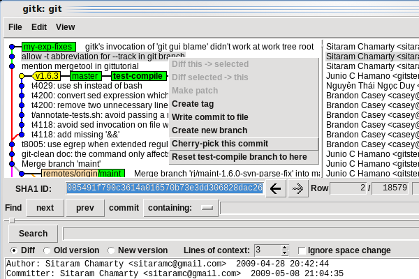

#### cherry-pick one more

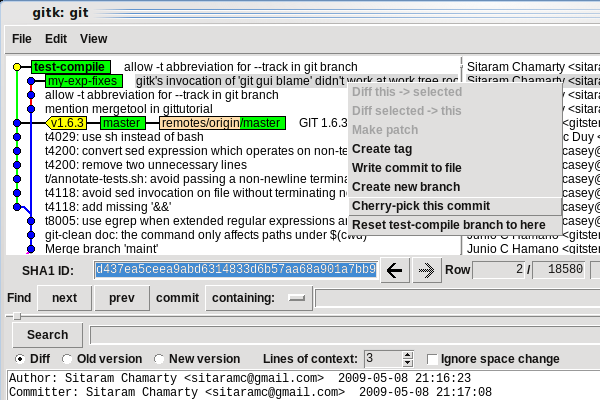

#### end result

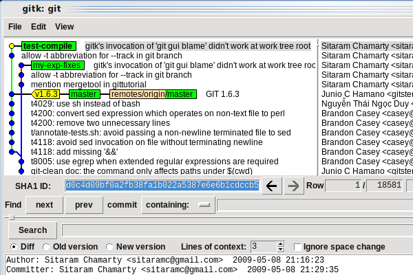

# rebase – what and why

- what
- why
  - parallel and serial branching
  - getting the best out of bisect

# rebase – when and how

- killing off an old commit
- re-arranging your commits interactively – demo 11
- **when not to use it!**
- origin has moved
  - demo 12 – parallel branch using merge
  - demo 13 – serial branch using rebase
- same, but after some of your changes have gone upstream
  - and they have DIFFERENT SHA1s now!!

#### starting point for interactive rebase

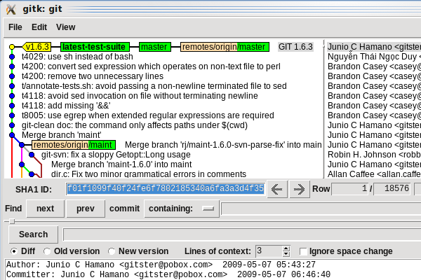

- and now we do:
  - `git rebase -i HEAD~8`

#### list of commits

(oldest first, waiting to be edited)

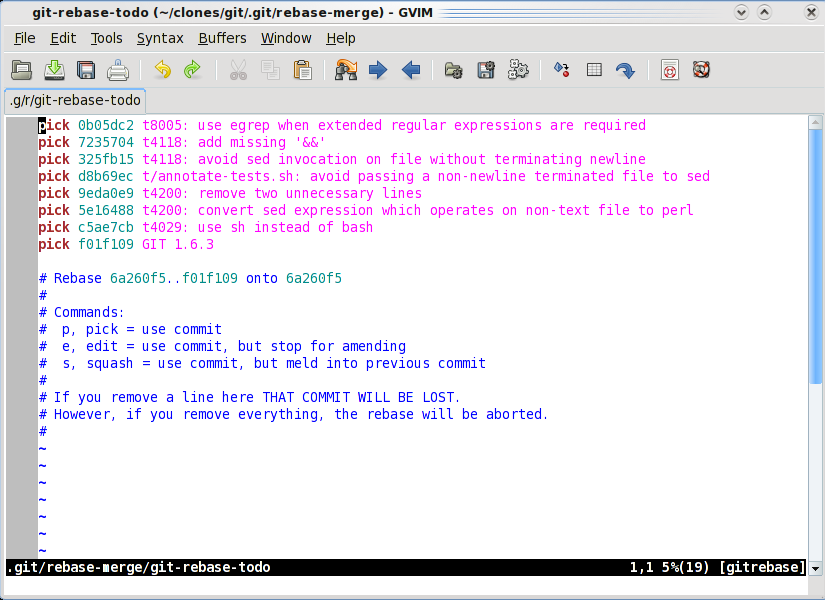

#### made some changes

then save, exit editor (note sequence and command words)

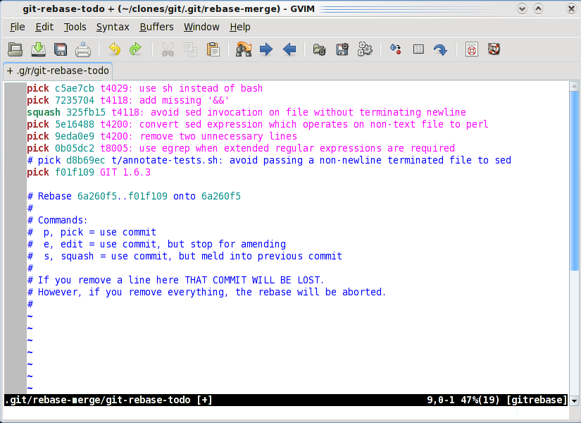

#### combined commit message for ‘squash’

[figure not shown]

#### edit as needed and save

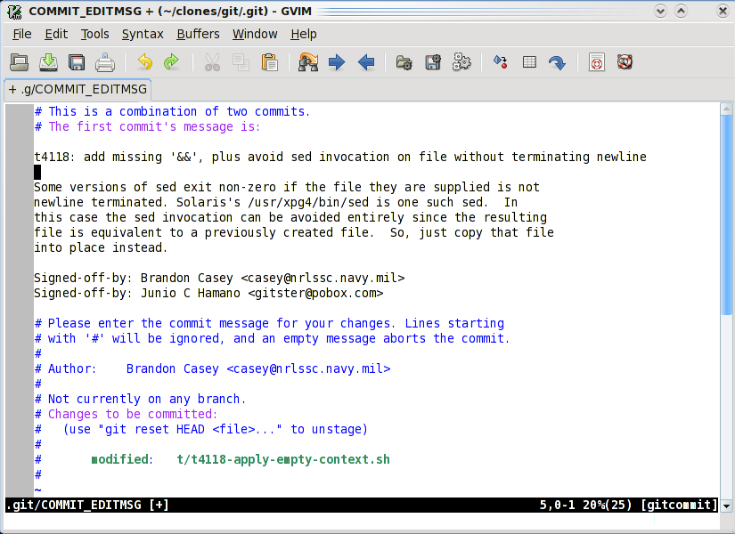

#### end result

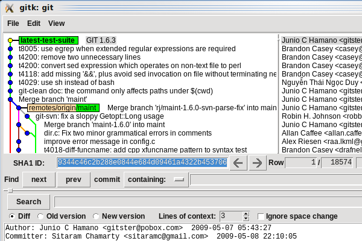

#### starting point for a merge

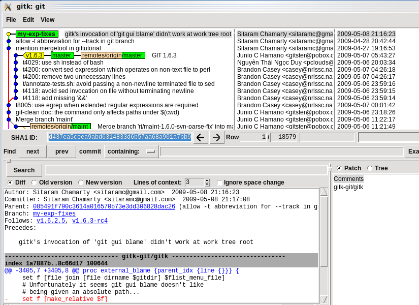

#### start a merge in ‘git gui’

[figure not shown]